# Tutorial 6

## Decision Tree Tuning

In the last tutorial we covered the basics of decision tree algorithm using caret library. In this tutorial we will cover how to potentially improve the performance of decision trees by tuning appropriate parameters.

### Parameter Space Outcomes

We should start by addressing some of the limitations of caret’s rpart decision trees. By default caret’s *rpart* algorithm takes a greedy approach when generating the tree. More specifically it tries to optimize the tree by optimizing the value of the *cp* (complexity) parameter. Just like *minsplit*, *maxdepth*, and *minbucket*, *cp* also is a hyperparameter. Although this approach generates very good results in general, it doesn’t always give you the optimal result because it doesn’t consider the other parameters during the *cp* optimization. An ideal solution should follow a *grid search* type of approach where you consider a combination of multiple different predictors.

To get a more customizable decision tree algorithm, we need to use the decision tree hyperparameters from the *rpart* library. To start let’s load the libraries we will use.

```r
library(caret)
```

```r
library(rpart)
library(tidyverse)
```

```r
library(ggplot2)
```

For this example we will use the diamonds dataset. The target variable will be “*cut*”.

```r
# Display the dataset
head(diamonds)
```

```
## # A tibble: 6 x 10
##   carat cut       color clarity depth table price     x     y     z
##   <dbl> <ord>     <ord> <ord>   <dbl> <dbl> <int> <dbl> <dbl> <dbl>
## 1 0.23  Ideal     E     SI2      61.5    55   326  3.95  3.98  2.43
## 2 0.21  Premium   E     SI1      59.8    61   326  3.89  3.84  2.31
## 3 0.23  Good      E     VS1      56.9    65   327  4.05  4.07  2.31
## 4 0.290 Premium   I     VS2      62.4    58   334  4.2   4.23  2.63
## 5 0.31  Good      J     SI2      63.3    58   335  4.34  4.35  2.75
## 6 0.24  Very Good J     VVS2     62.8    57   336  3.94  3.96  2.48
```

```r
# Display the number of entries
nrow(diamonds)
```

```
## [1] 53940
```

Let’s start with the base model here. We will use the *rpart1SE* method from caret library. The function is very similar to caret’s *rpart* we used before except here the algorithm doesn’t prune the tree for you. The original rpart method greedily prunes the tree using the cp parameter which might force you into a local minima. The *cp* by itself is a very strict parameter and it overwrites some of our target variables like *minsplit*, *maxdepth*, and *minbucket* because in the end they all rely on the complexity of the model.

Rpart1SE here also runs an optimization process under the hood but it doesn’t do it on any of the hyperparameters. Instead it builds a lot of possible models and picks the smallest one within the boundary of 1 Standard Error (1SE). This gives you a decent starting point but it’s not as restrictive as the original rpart method. You can easily improve your model performance by tuning the hyperparameters.

```r
set.seed(94)
train_control = trainControl(method = "cv", number = 10)

# Coerce target variable as factor for Confusion Matrix
diamonds$cut <- as.factor(diamonds$cut)

# Fit the model
tree1 <- train(cut ~., data = diamonds, method = "rpart1SE", trControl = train_control)
tree1
```

```
## CART
##
## 53940 samples
##     9 predictor
##     5 classes: 'Fair', 'Good', 'Very Good', 'Premium', 'Ideal'
##
## No pre-processing
## Resampling: Cross-Validated (10 fold)
## Summary of sample sizes: 48545, 48545, 48546, 48545, 48547, 48546, ...
## Resampling results:
##
##   Accuracy   Kappa
##   0.7086764  0.5812043
```

```r
# Evaluate the fit with a confusion matrix
pred_tree <- predict(tree1, diamonds)
# Confusion Matrix
confusionMatrix(diamonds$cut, pred_tree)
```

```
## Confusion Matrix and Statistics
##
##            Reference
## Prediction   Fair  Good Very Good Premium Ideal
##   Fair       1211   240        13     119    27
##   Good        161  2422      1053    1121   149
##   Very Good    16   746      2214    5498  3608
##   Premium       0     0         0   12099  1692
##   Ideal        14    24        57    1184 20272
##
## Overall Statistics
##
##                Accuracy : 0.7085
##                  95% CI : (0.7047, 0.7124)
##     No Information Rate : 0.4773
##     P-Value [Acc > NIR] : < 2.2e-16
##
##                   Kappa : 0.58
##
##  Mcnemar's Test P-Value : < 2.2e-16
##
## Statistics by Class:
##
##                      Class: Fair Class: Good Class: Very Good Class: Premium
## Sensitivity              0.86377     0.70571          0.66347         0.6043
## Specificity              0.99241     0.95082          0.80499         0.9501
## Pos Pred Value           0.75217     0.49368          0.18325         0.8773
## Neg Pred Value           0.99635     0.97940          0.97317         0.8027
## Prevalence               0.02599     0.06363          0.06187         0.3712
## Detection Rate           0.02245     0.04490          0.04105         0.2243
## Detection Prevalence     0.02985     0.09095          0.22399         0.2557
## Balanced Accuracy        0.92809     0.82827          0.73423         0.7772
##                      Class: Ideal
## Sensitivity                0.7873
## Specificity                0.9546
## Pos Pred Value             0.9407
## Neg Pred Value             0.8309
## Prevalence                 0.4773
## Detection Rate             0.3758
## Detection Prevalence       0.3995
## Balanced Accuracy          0.8710
```

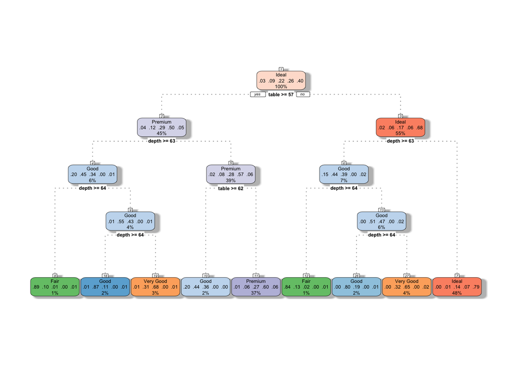

```r
# Visualize your decision tree
fancyRpartPlot(tree1$finalModel, caption = "")
```

For a brief comparison, we can also generate the rpart decision tree. This version comes in tuned automatically, and as you can see below it can actually perform worse in some situations.(0.71 vs 0.64 accuracy after 10-fold cross validation)

```r
train_control = trainControl(method = "cv", number = 10)
# Fit the model
tree_caret <- train(cut ~., data = diamonds, method = "rpart", trControl = train_control)
# Evaluate fit
tree_caret
```

```
## CART
##
## 53940 samples
##     9 predictor
##     5 classes: 'Fair', 'Good', 'Very Good', 'Premium', 'Ideal'
##
## No pre-processing
## Resampling: Cross-Validated (10 fold)
## Summary of sample sizes: 48545, 48547, 48546, 48546, 48546, 48546, ...
## Resampling results across tuning parameters:
##
##   cp          Accuracy   Kappa
##   0.04337892  0.6430857  0.4819975
##   0.05193121  0.6134212  0.4258976
##   0.33622526  0.4995736  0.1989137
##
## Accuracy was used to select the optimal model using the largest value.
## The final value used for the model was cp = 0.04337892.
```

The *rpart1SE* function here gets you the general accuracy score ~0.71. By default this function uses the following default parameters: minsplit = 20, minbucket = round(minsplit/3), cp = 0.01, maxdepth = 30. Now let’s see if we can improve this score by manual parameter tuning. Grid search we used earlier from the caret library doesn’t work here because hyperparameters we use are defined outside of the caret library, so you would have to define your own functions to do a grid search. If you are interested in how to do this in R you can check out this link: “https://rpubs.com/JiawenQi/GridSearchIris”

For the manual model building, we will be using the *rpart.control* function from the rpart library. With this, you can set all the hyperparameters that you would like to use. As a general approach you want to test your extremes first and move on to more acceptable values. Let’s start by testing with the maxdepth. Our current and maximum depth is 4 since the algorithm reaches the leaf nodes after 4. However, as we decrease this parameter our overall accuracy score decreases (~69%).

```r
# Fit the model
tree2 <- train(cut ~., data = diamonds, control = rpart.control(maxdepth = 3), trControl = train_control, method = "rpart1SE")
tree2
```

```
## CART
##
## 53940 samples
##     9 predictor
##     5 classes: 'Fair', 'Good', 'Very Good', 'Premium', 'Ideal'
##
## No pre-processing
## Resampling: Cross-Validated (10 fold)
## Summary of sample sizes: 48546, 48545, 48546, 48546, 48546, 48546, ...
## Resampling results:
##
##   Accuracy   Kappa
##   0.6856322  0.5511799
```

```r
# Evaluate the fit with a confusion matrix
pred_tree2 <- predict(tree2, diamonds)
# Confusion Matrix
confusionMatrix(diamonds$cut, pred_tree2)
```

```
## Confusion Matrix and Statistics
##
##            Reference
## Prediction   Fair  Good Very Good Premium Ideal
##   Fair       1211   253         0     119    27
##   Good        161  3475         0    1121   149
##   Very Good    16  2960         0    5498  3608
##   Premium       0     0         0   12099  1692
##   Ideal        14    81         0    1184 20272
##
## Overall Statistics
##
##                Accuracy : 0.687
##                  95% CI : (0.6831, 0.6909)
##     No Information Rate : 0.4773
##     P-Value [Acc > NIR] : < 2.2e-16
##
##                   Kappa : 0.5543
##
##  Mcnemar's Test P-Value : < 2.2e-16
##
## Statistics by Class:
##
##                      Class: Fair Class: Good Class: Very Good Class: Premium
## Sensitivity              0.86377     0.51337               NA         0.6043
## Specificity              0.99241     0.96966            0.776         0.9501
## Pos Pred Value           0.75217     0.70832               NA         0.8773
## Neg Pred Value           0.99635     0.93282               NA         0.8027
## Prevalence               0.02599     0.12549            0.000         0.3712
## Detection Rate           0.02245     0.06442            0.000         0.2243
## Detection Prevalence     0.02985     0.09095            0.224         0.2557
## Balanced Accuracy        0.92809     0.74152               NA         0.7772
##                      Class: Ideal
## Sensitivity                0.7873
## Specificity                0.9546
## Pos Pred Value             0.9407
## Neg Pred Value             0.8309
## Prevalence                 0.4773
## Detection Rate             0.3758
## Detection Prevalence       0.3995
## Balanced Accuracy          0.8710
```

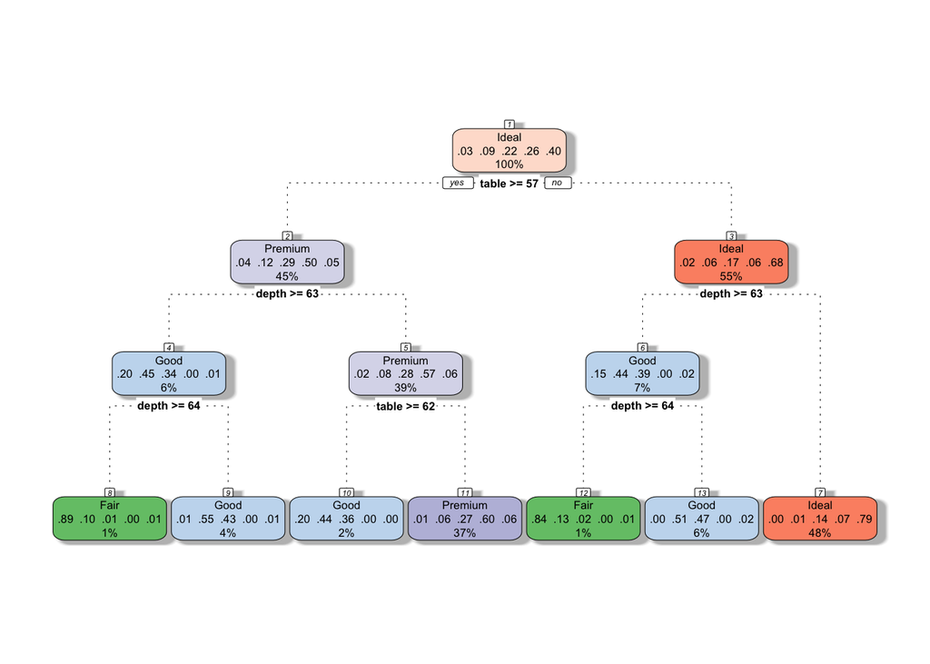

```r
# Visualize your decision tree
fancyRpartPlot(tree2$finalModel, caption = "")
```

If we want to try multiple parameters at once we just need to edit the control parameter. Let’s try to change all the hyperparameters at once. Minsplit is the minimum number of observations that must exist in a node in order for a split to be attempted. Since we have over 50000 entries in our dataset, testing with a high number like 5000 as opposed to the default value might be a good start. Similarly minbucket requires a higher number to make a reasonable change here since it is the minimum number of observations in any terminal leaf node.

```r
# Set hyperparameters
hypers = rpart.control(minsplit =  5000, maxdepth = 4, minbucket = 2500)

# Fit the model
tree2 <- train(cut ~., data = diamonds, control = hypers, trControl = train_control, method = "rpart1SE")

# Evaluate the fit with a confusion matrix
pred_tree2 <- predict(tree2, diamonds)
# Confusion Matrix
confusionMatrix(diamonds$cut, pred_tree2)
```

```
## Confusion Matrix and Statistics
##
##            Reference
## Prediction   Fair  Good Very Good Premium Ideal
##   Fair          0  1242         0     341    27
##   Good          0  3157         0    1600   149
##   Very Good     0  2589         0    5885  3608
##   Premium       0     0         0   12099  1692
##   Ideal         0    94         0    1185 20272
##
## Overall Statistics
##
##                Accuracy : 0.6587
##                  95% CI : (0.6546, 0.6627)
##     No Information Rate : 0.4773
##     P-Value [Acc > NIR] : < 2.2e-16
##
##                   Kappa : 0.5105
##
##  Mcnemar's Test P-Value : NA
##
## Statistics by Class:
##
##                      Class: Fair Class: Good Class: Very Good Class: Premium
## Sensitivity                   NA     0.44578               NA         0.5731
## Specificity              0.97015     0.96267            0.776         0.9485
## Pos Pred Value                NA     0.64350               NA         0.8773
## Neg Pred Value                NA     0.91995               NA         0.7756
## Prevalence               0.00000     0.13129            0.000         0.3914
## Detection Rate           0.00000     0.05853            0.000         0.2243
## Detection Prevalence     0.02985     0.09095            0.224         0.2557
## Balanced Accuracy             NA     0.70423               NA         0.7608
##                      Class: Ideal
## Sensitivity                0.7873
## Specificity                0.9546
## Pos Pred Value             0.9407
## Neg Pred Value             0.8309
## Prevalence                 0.4773
## Detection Rate             0.3758
## Detection Prevalence       0.3995
## Balanced Accuracy          0.8710
```

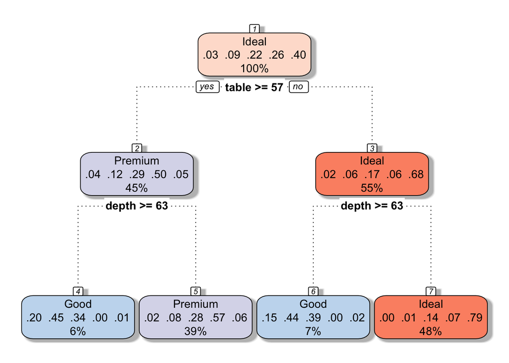

```r
# Visualize your decision tree
fancyRpartPlot(tree2$finalModel, caption = "")
```

Again we get a lower accuracy score on our predictions on the training set after simplifying our model. This could be due to the nature of our target class. Here some of the labels actually require higher complexity (deeper trees) to be classified properly.

### Test vs Train Performances

Now that we know how to tune hyperparameters, let’s actually use them to attempt to improve our model performance on the test set. Decision tree algorithms tend to overfit on the training data. In the real world, we are usually tasked to make predictions on the unseen data using the data we have available to train our model. Therefore evaluating performance on the unseen data is considered more important.

Let’s start by partitioning our data into 70% train and 30% test sets.

```r
# Partition the data
index = createDataPartition(y=diamonds$cut, p=0.7, list=FALSE)
# Everything in the generated index list
train_set = diamonds[index,]
```

```r
# Everything except the generated indices
test_set = diamonds[-index,]
```

Using the training set we build our model and make predictions on the test set for evaluations. We will do this with the default hyper parameters.

```r
# Fit the model
tree1 <- train(cut ~., data = train_set, method = "rpart1SE", trControl = train_control)

# Evaluate the fit with a confusion matrix
pred_tree <- predict(tree1, test_set)
# Confusion Matrix
confusionMatrix(test_set$cut, pred_tree)
```

```
## Confusion Matrix and Statistics
##
##            Reference
## Prediction  Fair Good Very Good Premium Ideal
##   Fair       353   82         2      41     5
##   Good        47  735       305     348    36
##   Very Good    3  203       812    1696   910
##   Premium      0    0        42    3623   472
##   Ideal        4    9       147     367  5938
##
## Overall Statistics
##
##                Accuracy : 0.7083
##                  95% CI : (0.7013, 0.7153)
##     No Information Rate : 0.4549
##     P-Value [Acc > NIR] : < 2.2e-16
##
##                   Kappa : 0.5819
##
##  Mcnemar's Test P-Value : < 2.2e-16
##
## Statistics by Class:
##
##                      Class: Fair Class: Good Class: Very Good Class: Premium
## Sensitivity              0.86732     0.71429          0.62080         0.5964
## Specificity              0.99176     0.95142          0.81092         0.9491
## Pos Pred Value           0.73085     0.49966          0.22406         0.8758
## Neg Pred Value           0.99656     0.98001          0.96050         0.7964
## Prevalence               0.02515     0.06360          0.08084         0.3755
## Detection Rate           0.02182     0.04543          0.05019         0.2239
## Detection Prevalence     0.02985     0.09091          0.22398         0.2557
## Balanced Accuracy        0.92954     0.83285          0.71586         0.7728
##                      Class: Ideal
## Sensitivity                0.8067
## Specificity                0.9402
## Pos Pred Value             0.9185
## Neg Pred Value             0.8535
## Prevalence                 0.4549
## Detection Rate             0.3670
## Detection Prevalence       0.3996
## Balanced Accuracy          0.8735
```

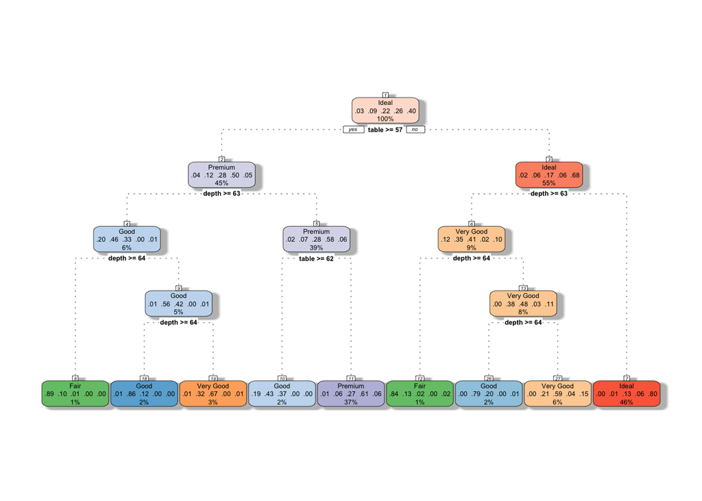

```r
# Visualize your decision tree
fancyRpartPlot(tree1$finalModel, caption = "")
```

Here we ended up with an accuracy score that is very close to the score from the training set. Judging by this we can safely suspect that there might not be any overfitting in the data. To make sure, let’s use the set of hyperparameters we had from the part before that simplified the complexity our model.

```r
# Set hyperparameters
hypers = rpart.control(minsplit =  5000, maxdepth = 4, minbucket = 2500)

# Fit the model
tree2 <- train(cut ~., data = train_set, control = hypers, trControl = train_control, method = "rpart1SE")

# Evaluate the fit with a confusion matrix
pred_tree <- predict(tree2, test_set)
# Confusion Matrix
confusionMatrix(test_set$cut, pred_tree)
```

```
## Confusion Matrix and Statistics
##
##            Reference
## Prediction  Fair Good Very Good Premium Ideal
##   Fair         0  187       173     118     5
##   Good         0  413       529     493    36
##   Very Good    0  437       593    1684   910
##   Premium      0  136        42    3487   472
##   Ideal        0   16       150     361  5938
##
## Overall Statistics
##
##                Accuracy : 0.6447
##                  95% CI : (0.6373, 0.6521)
##     No Information Rate : 0.4549
##     P-Value [Acc > NIR] : < 2.2e-16
##
##                   Kappa : 0.4879
##
##  Mcnemar's Test P-Value : < 2.2e-16
##
## Statistics by Class:
##
##                      Class: Fair Class: Good Class: Very Good Class: Premium
## Sensitivity                   NA     0.34735          0.39879         0.5676
## Specificity              0.97015     0.92942          0.79371         0.9352
## Pos Pred Value                NA     0.28076          0.16363         0.8429
## Neg Pred Value                NA     0.94724          0.92880         0.7795
## Prevalence               0.00000     0.07349          0.09190         0.3797
## Detection Rate           0.00000     0.02553          0.03665         0.2155
## Detection Prevalence     0.02985     0.09091          0.22398         0.2557
## Balanced Accuracy             NA     0.63839          0.59625         0.7514
##                      Class: Ideal
## Sensitivity                0.8067
## Specificity                0.9402
## Pos Pred Value             0.9185
## Neg Pred Value             0.8535
## Prevalence                 0.4549
## Detection Rate             0.3670
## Detection Prevalence       0.3996
## Balanced Accuracy          0.8735
```

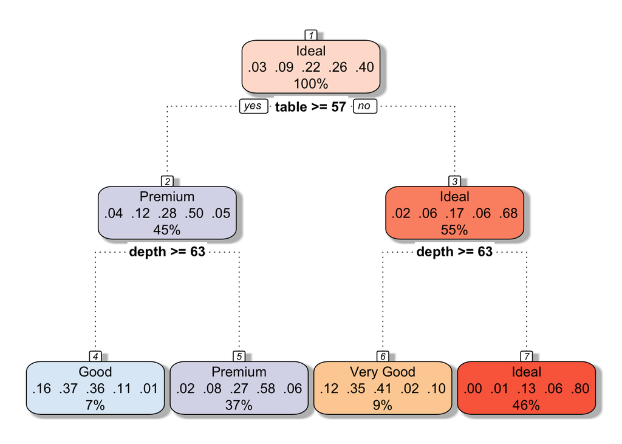

```r
# Visualize your decision tree
fancyRpartPlot(tree2$finalModel, caption = "")
```

Our simplified tree here performs worse than the default hyper parameters model. There is no sign of overfitting present in these models, therefore parameter tuning to simplify our model might not be beneficial here.

## General Model Comparison & Visualization

To compare the performance of multiple models we will need to compare their train versus test set accuracies. There are few ways to do it, but most of them will require you to use loops and data structures. Most of these methods are out of scope for this class. However using a data frame structure in R, we can create a table with the hyperparameters, accuracy scores, and the number of nodes.

The decision tree object is a massive object containing the entire model, model results, information on the training data etc. Utilizing this object we can access a lot of information on the decision tree we built.

The tree structure is saved inside the *finalModel* parameter in an attribute called *frame*. Each node is represented as a row and the *nrow* function can give you the number of rows/nodes.

The accuracy scores on the other hand will need to be calculated first. Luckily the confusion matrix does this calculation for us. The *confusionMatrix* function actually returns a confusion matrix object with the overall accuracy score. Running this once for each prediction, once for both training and test sets, we can access the overall accuracy score for our models. *overall* parameter in the confusion matrix object returns a set of metrics and the first one of those is the accuracy score. You can index this by *overall[1]*.

Combining these two model metrics we can form a table of values for model comparison.

```r
# Initialize cross validation
train_control = trainControl(method = "cv", number = 10)

# Tree 1
hypers = rpart.control(minsplit =  2, maxdepth = 1, minbucket = 2)
tree1 <- train(cut ~., data = train_set, control = hypers, trControl = train_control, method = "rpart1SE")

# Training Set
# Evaluate the fit with a confusion matrix
pred_tree <- predict(tree1, train_set)
# Confusion Matrix
cfm_train <- confusionMatrix(train_set$cut, pred_tree)

# Test Set
# Evaluate the fit with a confusion matrix
pred_tree <- predict(tree1, test_set)
# Confusion Matrix
cfm_test <- confusionMatrix(test_set$cut, pred_tree)

# Get training accuracy
a_train <- cfm_train$overall[1]
# Get testing accuracy
a_test <- cfm_test$overall[1]
# Get number of nodes
nodes <- nrow(tree1$finalModel$frame)

# Form the table
comp_tbl <- data.frame("Nodes" = nodes, "TrainAccuracy" = a_train, "TestAccuracy" = a_test,
                       "MaxDepth" = 1, "Minsplit" = 2, "Minbucket" = 2)

# Tree 2
hypers = rpart.control(minsplit =  5, maxdepth = 2, minbucket = 5)
tree2 <- train(cut ~., data = train_set, control = hypers, trControl = train_control, method = "rpart1SE")

# Training Set
# Evaluate the fit with a confusion matrix
pred_tree <- predict(tree2, train_set)
# Confusion Matrix
cfm_train <- confusionMatrix(train_set$cut, pred_tree)

# Test Set
# Evaluate the fit with a confusion matrix
pred_tree <- predict(tree2, test_set)
# Confusion Matrix
cfm_test <- confusionMatrix(test_set$cut, pred_tree)

# Get training accuracy
a_train <- cfm_train$overall[1]
# Get testing accuracy
a_test <- cfm_test$overall[1]
# Get number of nodes
nodes <- nrow(tree2$finalModel$frame)

# Add rows to the table - Make sure the order is correct
comp_tbl <- comp_tbl %>% rbind(list(nodes, a_train, a_test, 2, 5, 5))

# Tree 3
hypers = rpart.control(minsplit = 50, maxdepth = 3, minbucket = 50)
tree4 <- train(cut ~., data = train_set, control = hypers, trControl = train_control, method = "rpart1SE")

# Training Set
# Evaluate the fit with a confusion matrix
pred_tree <- predict(tree4, train_set)
# Confusion Matrix
cfm_train <- confusionMatrix(train_set$cut, pred_tree)

# Test Set
# Evaluate the fit with a confusion matrix
pred_tree <- predict(tree4, test_set)
# Confusion Matrix
cfm_test <- confusionMatrix(test_set$cut, pred_tree)

# Get training accuracy
a_train <- cfm_train$overall[1]
# Get testing accuracy
a_test <- cfm_test$overall[1]
# Get number of nodes
nodes <- nrow(tree4$finalModel$frame)

# Add rows to the table - Make sure the order is correct
comp_tbl <- comp_tbl %>% rbind(list(nodes, a_train, a_test, 3, 50, 50))


# Tree 4
hypers = rpart.control(minsplit = 100, maxdepth = 4, minbucket = 100)
tree7 <- train(cut ~., data = train_set, control = hypers, trControl = train_control, method = "rpart1SE")

# Training Set
# Evaluate the fit with a confusion matrix
pred_tree <- predict(tree7, train_set)
# Confusion Matrix
cfm_train <- confusionMatrix(train_set$cut, pred_tree)

# Test Set
# Evaluate the fit with a confusion matrix
pred_tree <- predict(tree7, test_set)
# Confusion Matrix
cfm_test <- confusionMatrix(test_set$cut, pred_tree)

# Get training accuracy
a_train <- cfm_train$overall[1]
# Get testing accuracy
a_test <- cfm_test$overall[1]
# Get number of nodes
nodes <- nrow(tree7$finalModel$frame)

# Add rows to the table - Make sure the order is correct
comp_tbl <- comp_tbl %>% rbind(list(nodes, a_train, a_test, 4, 100, 100))

# Tree 5
hypers = rpart.control(minsplit = 1000, maxdepth = 4, minbucket = 1000)
tree8 <- train(cut ~., data = train_set, control = hypers, trControl = train_control, method = "rpart1SE")

# Training Set
# Evaluate the fit with a confusion matrix
pred_tree <- predict(tree8, train_set)
# Confusion Matrix
cfm_train <- confusionMatrix(train_set$cut, pred_tree)

# Test Set
# Evaluate the fit with a confusion matrix
pred_tree <- predict(tree8, test_set)
# Confusion Matrix
cfm_test <- confusionMatrix(test_set$cut, pred_tree)

# Get training accuracy
a_train <- cfm_train$overall[1]
# Get testing accuracy
a_test <- cfm_test$overall[1]
# Get number of nodes
nodes <- nrow(tree8$finalModel$frame)

# Add rows to the table - Make sure the order is correct
comp_tbl <- comp_tbl %>% rbind(list(nodes, a_train, a_test, 4, 1000, 1000))

# Tree 6
hypers = rpart.control(minsplit = 5000, maxdepth = 8, minbucket = 5000)
tree10 <- train(cut ~., data = train_set, control = hypers, trControl = train_control, method = "rpart1SE")

# Training Set
# Evaluate the fit with a confusion matrix
pred_tree <- predict(tree10, train_set)
# Confusion Matrix
cfm_train <- confusionMatrix(train_set$cut, pred_tree)

# Test Set
# Evaluate the fit with a confusion matrix
pred_tree <- predict(tree10, test_set)
# Confusion Matrix
cfm_test <- confusionMatrix(test_set$cut, pred_tree)

# Get training accuracy
a_train <- cfm_train$overall[1]
# Get testing accuracy
a_test <- cfm_test$overall[1]
# Get number of nodes
nodes <- nrow(tree10$finalModel$frame)

# Add rows to the table - Make sure the order is correct
comp_tbl <- comp_tbl %>% rbind(list(nodes, a_train, a_test, 8, 5000, 5000))

# Tree 7
hypers = rpart.control(minsplit = 10000, maxdepth = 25, minbucket = 10000)
tree11 <- train(cut ~., data = train_set, control = hypers, trControl = train_control, method = "rpart1SE")

# Training Set
# Evaluate the fit with a confusion matrix
pred_tree <- predict(tree11, train_set)
# Confusion Matrix
cfm_train <- confusionMatrix(train_set$cut, pred_tree)

# Test Set
# Evaluate the fit with a confusion matrix
pred_tree <- predict(tree11, test_set)
# Confusion Matrix
cfm_test <- confusionMatrix(test_set$cut, pred_tree)

# Get training accuracy
a_train <- cfm_train$overall[1]
# Get testing accuracy
a_test <- cfm_test$overall[1]
# Get number of nodes
nodes <- nrow(tree11$finalModel$frame)

# Add rows to the table - Make sure the order is correct
comp_tbl <- comp_tbl %>% rbind(list(nodes, a_train, a_test, 25, 10000, 10000))

comp_tbl
```

```
##          Nodes TrainAccuracy TestAccuracy MaxDepth Minsplit Minbucket
## Accuracy     3     0.6019862    0.6001854        1        2         2
## 2            7     0.6584481    0.6522868        2        5         5
## 3           13     0.6881356    0.6823857        3       50        50
## 4           17     0.7111494    0.7083436        4      100       100
## 5           11     0.6802966    0.6766996        4     1000      1000
## 6            5     0.6149629    0.6089617        8     5000      5000
## 7            3     0.6019862    0.6001854       25    10000     10000
```

Setting number of nodes as our x-axis we can visualize the varying accuracies using a scatter plot (some nodes might represent multiple accuracy points) or a line plot to see a trend in number of nodes versus accuracy.

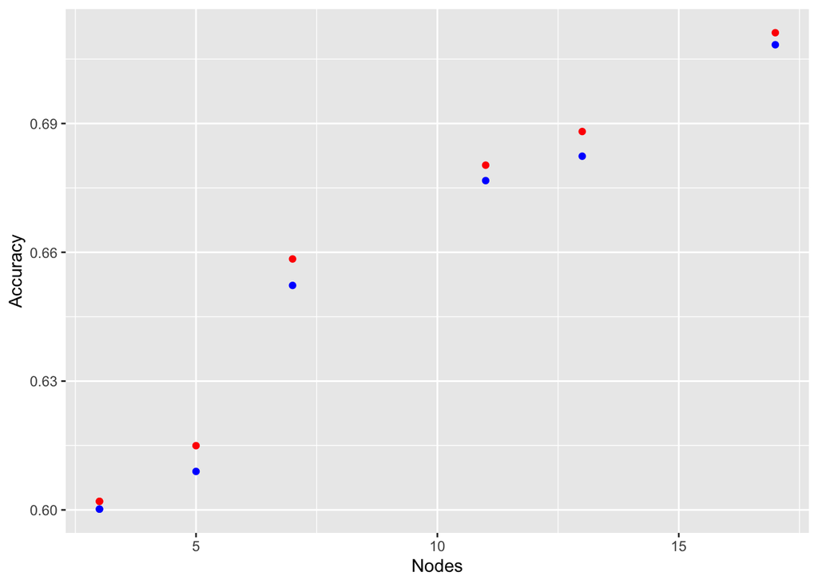

```r
# Visualize with scatter plot
ggplot(comp_tbl, aes(x=Nodes)) +
  geom_point(aes(y = TrainAccuracy), color = "red") +
  geom_point(aes(y = TestAccuracy), color="blue") +
  ylab("Accuracy")
```

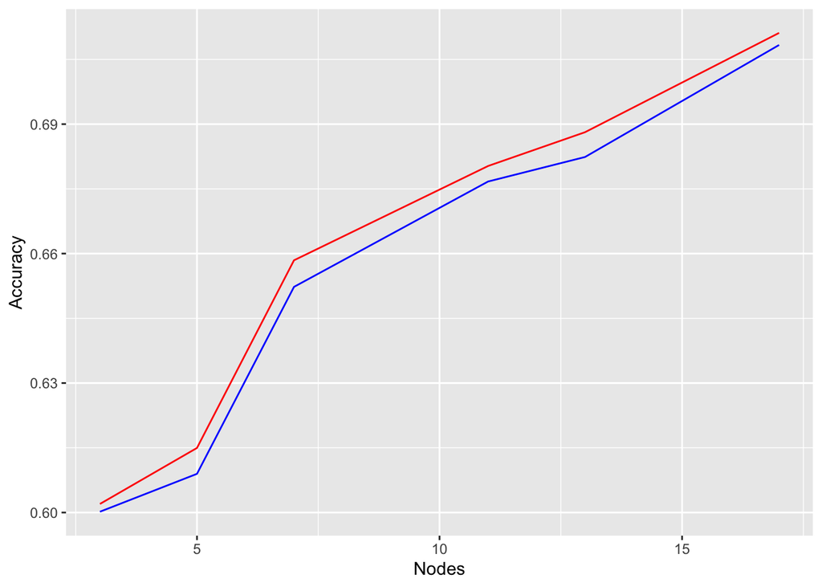

```r
# Visualize with line plot
ggplot(comp_tbl, aes(x=Nodes)) +
  geom_line(aes(y = TrainAccuracy), color = "red") +
  geom_line(aes(y = TestAccuracy), color="blue") +
  ylab("Accuracy")
```

## Feature Selection

In addition to the parameter tuning, we can also investigate our predictors to improve our model performance. Feature selection can also be used to reduce the number of dimensions.

### Relevance analysis (variable importance score)

The first option for feature selection is analyzing the variable importance scores. These scores can be used to rank how significant each predictor is. Using this information we can reduce the number of dimensions or reach conclusions about our underlying model. Caret version of the decision tree has this available with the function *varImp*.

```r
# View the predictors present in the model
colnames(diamonds)
```

```
##  [1] "carat"   "cut"     "color"   "clarity" "depth"   "table"   "price"
##  [8] "x"       "y"       "z"
```

```r
# Fit the model
tree1 <- train(cut ~., data = train_set, method = "rpart1SE", trControl = train_control)

# View the variable importance scores
var_imp <- varImp(tree1, scale = FALSE)
var_imp
```

```
## rpart1SE variable importance
##
##             Overall
## depth       7057.99
## table       6508.14
## x            830.03
## carat        765.81
## y            404.91
## z            382.21
## clarity.L    232.47
## price         78.28
## clarity.Q     18.46
## color.L        0.00
## color.Q        0.00
## `clarity^6`    0.00
## color.C        0.00
## `clarity^7`    0.00
## `color^5`      0.00
## `clarity^5`    0.00
## clarity.C      0.00
## `color^4`      0.00
## `clarity^4`    0.00
## `color^6`      0.00
```

We can also easily visualize the variable importance scores using the *plot* function. The output from the *varImp* function handles the printing and plotting outputs for you, so you don’t have to worry about formatting your output in any way.

```r
# Estimate variable importance
importance <- varImp(tree1, scale=FALSE)
# Summarize importance
print(importance)
```

```
## rpart1SE variable importance
##
##             Overall
## depth       7057.99
## table       6508.14
## x            830.03
## carat        765.81
## y            404.91
## z            382.21
## clarity.L    232.47
## price         78.28
## clarity.Q     18.46
## `clarity^4`    0.00
## clarity.C      0.00
## `clarity^5`    0.00
## `color^6`      0.00
## `color^4`      0.00
## color.Q        0.00
## color.L        0.00
## color.C        0.00
## `clarity^7`    0.00
## `clarity^6`    0.00
## `color^5`      0.00
```

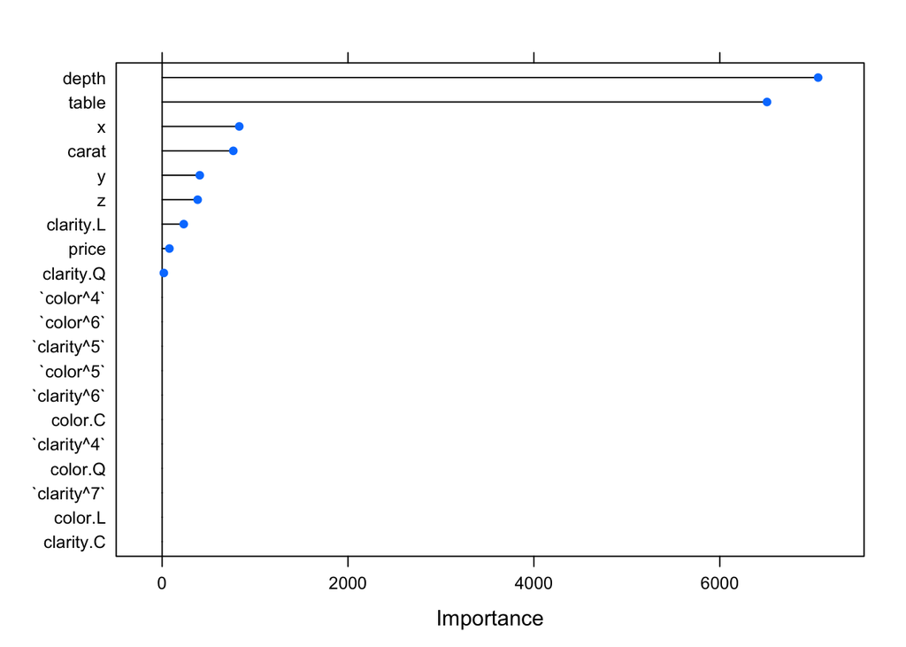

```r
# Visualize
plot(importance)
```

Relevance analysis here reveals that we get most of significant contributions from only 2 variables, table and depth. We can also confirm this by looking at the decision tree plot. However, in some cases the tree will be too large and determining the significance of the predictors will have to rely on variable importance scores. Using the scores from variable importance analysis, we can reduce the size of our table and only keep the relevant predictors.

### Recursive Feature Elimination

Instead of following a greedy approach and eliminating features based on their individual variable importance scores, we can utilize recursion and make our decisions on a set of predictors. **Recursive feature elimination** is one of these methods that builds multiple models for comparison. The main idea is very similar to forward and backward elimination, the only difference is the approach used for creating these sets. Recursive feature elimination resamples the data at each step to eliminate the selection bias. However, as a result of this, the runtimes are significantly slower for this approach. Any dataset larger than 1000 rows can result into significantly slow runtimes.

Since the diamonds dataset has about 54000 rows, using that dataset for this portion isn’t ideal. However, if you really would like to use this approach with a large dataset you can always properly resample your dataset. For this example, we will be using the Pima Indians Diabetes dataset. It has 768 rows which is perfect for recursive feature elimination.

```r
# The data comes with the mlbench library
library(mlbench)
# Load the data
data("PimaIndiansDiabetes")
# Partition the data
index = createDataPartition(y=PimaIndiansDiabetes$diabetes, p=0.7, list=FALSE)
# Everything in the generated index list
train_set = PimaIndiansDiabetes[index,]
# Everything except the generated indices
test_set = PimaIndiansDiabetes[-index,]
```

The first step is defining the control parameters for the function using *rfeControl*. This step is almost identical to defining train control except the functions parameter. Functions parameter here requires rfFuncs because we are evaluating a decision tree performance. Any regression for example will require lmFuncs. Then you just call the *rfe* function. Be careful here though, because x and y variables of this function requires the data to be in the list form. Indexing method used below does this automatically or you can coerce using *as.list*.

```r
# Define the control using a random forest selection function
control <- rfeControl(functions=rfFuncs, method="cv", number=10)
# Run the RFE algorithm
results <- rfe(x = PimaIndiansDiabetes[,1:8], y = PimaIndiansDiabetes[,9], sizes=c(1:8), rfeControl=control)
# Summarize the results
print(results)
```

```
##
## Recursive feature selection
##
## Outer resampling method: Cross-Validated (10 fold)
##
## Resampling performance over subset size:
##
##  Variables Accuracy  Kappa AccuracySD KappaSD Selected
##          1   0.6979 0.2811    0.03401 0.06776
##          2   0.7356 0.3947    0.05039 0.10574
##          3   0.7422 0.4196    0.04703 0.09754
##          4   0.7474 0.4322    0.06021 0.12935
##          5   0.7461 0.4318    0.06358 0.14074
##          6   0.7590 0.4540    0.05793 0.12869
##          7   0.7591 0.4543    0.04903 0.10850
##          8   0.7617 0.4560    0.04514 0.10051        *
##
## The top 5 variables (out of 8):
##    glucose, mass, age, pregnant, insulin
```

The function output doesn’t give you the full list of predictors, if you want to see the full list you would have to call the *predictors* function. You can also generate a nice visualization of the accuracy scores by the number of predictors used by calling plot on your result.

```r
# List the chosen features in order
predictors(results)
```

```
## [1] "glucose"  "mass"     "age"      "pregnant" "insulin"  "pedigree" "triceps"
## [8] "pressure"
```

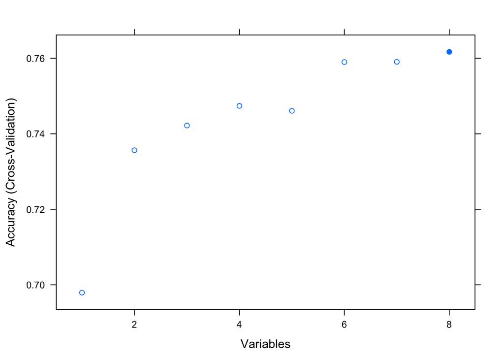

```r
# Plot the results
plot(results)
```